# Introduction

Categorical Feature Encoding Challenge: Kaggle Link

In this project the data file have lots of categorical features. We are asked to predict a binay target based on other features using various techniques of feature encodings.

# Data Description

```
# id features
'id',

# binary features
'bin_0', 'bin_1', 'bin_2', 'bin_3', 'bin_4',

# nominal features
'nom_0', 'nom_1','nom_2', 'nom_3', 'nom_4',
'nom_5', 'nom_6', 'nom_7', 'nom_8', 'nom_9',

# ordinal features
'ord_0', 'ord_1', 'ord_2', 'ord_3', 'ord_4', 'ord_5',

# cyclical features
 'day', 'month',

# binary target
'target'
```

# Types of Data

- **Continuous Data**
  - Numbers like 0.0, 0.1, ..., 100.0 etc are continuous data.
  - We can use histogram binnings to encode continuous data.
  - We can groupby features and use various statistics such as mean, max etc.
- **Categorical Data**
  - **Binary data** : Binary data has two values,e.g. 0/1, -1/1, True/False
  - **Categorical data** : Has few limited variables. E.g. 1-7 for weekdays.
  - **Ordinal data** : Has order in it. Eg. Movie review Bad,medium,Good.
  - **Nominal data** : Nominal values without order. E.g. USA,Nepal,Canada
- **Timeseries data** : These can be continuous and discrete. They have time associated with them. When using train-test split we should not shuffle them.

# Resources

- [Cyclical Features](https://ianlondon.github.io/blog/encoding-cyclical-features-24hour-time/)
- [An Overview of Encoding Techniques](https://www.kaggle.com/shahules/an-overview-of-encoding-techniques)
- [Cat in dat: OHE vs Thermometer + Logit](https://www.kaggle.com/pavelvpster/cat-in-dat-ohe-vs-thermometer-logit)

# Imports

```python
import numpy as np
import pandas as pd
import seaborn as sns
sns.set(color_codes=True)

import matplotlib
import matplotlib.pyplot as plt
%matplotlib inline
%config InlineBackend.figure_format = 'retina'
sns.set(context='notebook', style='whitegrid', rc={'figure.figsize': (12,8)})
plt.style.use('ggplot') # better than sns styles.
matplotlib.rcParams['figure.figsize'] = 12,8

import os
import time

# random state
SEED=100
np.random.seed(SEED)

# Jupyter notebook settings for pandas
#pd.set_option('display.float_format', '{:,.2g}'.format) # numbers sep by comma
from pandas.api.types import CategoricalDtype
np.set_printoptions(precision=3)
pd.set_option('display.max_columns', 100)
pd.set_option('display.max_rows', 100) # None for all the rows
pd.set_option('display.max_colwidth', 200)

import IPython
from IPython.display import display, HTML, Image, Markdown

print([(x.__name__,x.__version__) for x in [np, pd,sns,matplotlib]])
```

```
[('numpy', '1.17.4'), ('pandas', '0.25.3'), ('seaborn', '0.9.0'), ('matplotlib', '3.1.2')]
```

```python
ENV_BHISHAN = None

try:
    import bhishan
    ENV_BHISHAN = True
    print("Environment: Bhishan's Laptop")
except:
    pass


import sys
ENV_COLAB = 'google.colab' in sys.modules

if ENV_COLAB:
    # load google drive
    # from google.colab import drive
    # drive.mount('/content/drive')
    # dat_dir = 'drive/My Drive/Colab Notebooks/data/'
    # sys.path.append(dat_dir)

    # pip install
    #!pip install pyldavis
    #!pip install hyperopt
    # !pip install catboost
    #!pip install shap
    #!pip install eli5
    #!pip install lime

    # print
    print('Environment: Google Colaboratory.')

if ENV_COLAB:
    # update modules
    # !pip install -U scikit-learn
    # !pip install -U tqdm # tqdm needs restart run time.
    pass
```

```
Environment: Google Colaboratory.
```

```python
from pandas.api.types import is_string_dtype, is_numeric_dtype

from sklearn.preprocessing import OneHotEncoder
from sklearn.feature_extraction import FeatureHasher

from sklearn.model_selection import KFold

from sklearn.base import BaseEstimator, TransformerMixin

import scipy
```

# Load the Data

```python
ifile_train = 'https://github.com/bhishanpdl/Project_Categorical_Feature_Encoding/blob/master/data/raw/train.csv?raw=true'
ifile_test = 'https://github.com/bhishanpdl/Project_Categorical_Feature_Encoding/blob/master/data/raw/test.csv?raw=true'

df_train = pd.read_csv(ifile_train)
df_test = pd.read_csv(ifile_test)

df_train.drop('id', axis=1, inplace=True)
df_test.drop('id',axis=1,inplace=True)

print(df_train.shape, df_test.shape)
df_train.head()
```

```
(300000, 24) (200000, 23)
```

|  | bin_0 | bin_1 | bin_2 | bin_3 | bin_4 | nom_0 | nom_1 | nom_2 | nom_3 | nom_4 | nom_5 | nom_6 | nom_7 | nom_8 | nom_9 | ord_0 | ord_1 | ord_2 | ord_3 | ord_4 | ord_5 | day | month | target |
| --- | --- | --- | --- | --- | --- | --- | --- | --- | --- | --- | --- | --- | --- | --- | --- | --- | --- | --- | --- | --- | --- | --- | --- | --- |
| 0 | 0 | 0 | 0 | T | Y | Green | Triangle | Snake | Finland | Bassoon | 50f116bcf | 3ac1b8814 | 68f6ad3e9 | c389000ab | 2f4cb3d51 | 2 | Grandmaster | Cold | h | D | kr | 2 | 2 | 0 |
| 1 | 0 | 1 | 0 | T | Y | Green | Trapezoid | Hamster | Russia | Piano | b3b4d25d0 | fbcb50fc1 | 3b6dd5612 | 4cd920251 | f83c56c21 | 1 | Grandmaster | Hot | a | A | bF | 7 | 8 | 0 |
| 2 | 0 | 0 | 0 | F | Y | Blue | Trapezoid | Lion | Russia | Theremin | 3263bdce5 | 0922e3cb8 | a6a36f527 | de9c9f684 | ae6800dd0 | 1 | Expert | Lava Hot | h | R | Jc | 7 | 2 | 0 |
| 3 | 0 | 1 | 0 | F | Y | Red | Trapezoid | Snake | Canada | Oboe | f12246592 | 50d7ad46a | ec69236eb | 4ade6ab69 | 8270f0d71 | 1 | Grandmaster | Boiling Hot | i | D | kW | 2 | 1 | 1 |
| 4 | 0 | 0 | 0 | F | N | Red | Trapezoid | Lion | Canada | Oboe | 5b0f5acd5 | 1fe17a1fd | 04ddac2be | cb43ab175 | b164b72a7 | 1 | Grandmaster | Freezing | a | R | qP | 7 | 8 | 0 |

```python
df_test.head()
```

|  | bin_0 | bin_1 | bin_2 | bin_3 | bin_4 | nom_0 | nom_1 | nom_2 | nom_3 | nom_4 | nom_5 | nom_6 | nom_7 | nom_8 | nom_9 | ord_0 | ord_1 | ord_2 | ord_3 | ord_4 | ord_5 | day | month |
| --- | --- | --- | --- | --- | --- | --- | --- | --- | --- | --- | --- | --- | --- | --- | --- | --- | --- | --- | --- | --- | --- | --- | --- |
| 0 | 0 | 0 | 1 | T | Y | Blue | Triangle | Axolotl | Finland | Piano | 0870b0a5d | 9ceb19dd6 | 530f8ecc3 | 9d117320c | 3c49b42b8 | 2 | Novice | Warm | j | P | be | 5 | 11 |
| 1 | 0 | 0 | 0 | T | N | Red | Square | Lion | Canada | Piano | a5c276589 | 1ad744242 | 12e6161c9 | 46ae3059c | 285771075 | 1 | Master | Lava Hot | l | A | RP | 7 | 5 |
| 2 | 1 | 0 | 1 | F | Y | Blue | Square | Dog | China | Piano | 568550f04 | 1fe17a1fd | 27d6df03f | b759e21f0 | 6f323c53f | 2 | Expert | Freezing | a | G | tP | 1 | 12 |
| 3 | 0 | 0 | 1 | T | Y | Red | Star | Cat | China | Piano | c5725677e | a6542cec0 | 30c63bd0c | 0b6ec68ff | b5de3dcc4 | 1 | Contributor | Lava Hot | b | Q | ke | 2 | 3 |
| 4 | 0 | 1 | 1 | F | N | Red | Trapezoid | Dog | China | Piano | e70a6270d | 97b6a3518 | a42386065 | f91f3b1ee | 967cfa9c9 | 3 | Grandmaster | Lava Hot | l | W | qK | 4 | 11 |

```python
df_train.columns
```

```
Index(['bin_0', 'bin_1', 'bin_2', 'bin_3', 'bin_4', 'nom_0', 'nom_1', 'nom_2',
       'nom_3', 'nom_4', 'nom_5', 'nom_6', 'nom_7', 'nom_8', 'nom_9', 'ord_0',
       'ord_1', 'ord_2', 'ord_3', 'ord_4', 'ord_5', 'day', 'month', 'target'],
      dtype='object')
```

```python
[ (c,df_train[c].nunique()) for c in df_train.iloc[:,1:-1] ]
```

```
[('bin_1', 2),
 ('bin_2', 2),
 ('bin_3', 2),
 ('bin_4', 2),
 ('nom_0', 3),
 ('nom_1', 6),
 ('nom_2', 6),
 ('nom_3', 6),
 ('nom_4', 4),
 ('nom_5', 222),
 ('nom_6', 522),
 ('nom_7', 1220),
 ('nom_8', 2215),
 ('nom_9', 11981),
 ('ord_0', 3),
 ('ord_1', 5),
 ('ord_2', 6),
 ('ord_3', 15),
 ('ord_4', 26),
 ('ord_5', 192),
 ('day', 7),
 ('month', 12)]
```

```python
# df_train.info()
```

```python
# df_test.info()
```

```python
# as given in data description, the data set does not have any nulls.
```

# Train Target Split

```python
df_Xtrain = df_train.drop(['target'],axis=1)
ytrain = df_train['target'].to_numpy()
ytr = ytrain # in python variable is just a reference, no any memeory use.

df_Xtest = df_test # test does not have target column
```

# Train test object dtype

```python
df_train_obj = df_train.copy()
df_test_obj  = df_test.copy()

df_train_obj['day']   = df_train_obj['day'].astype('object')
df_train_obj['month'] = df_train_obj['month'].astype('object')

df_test_obj['day']   = df_test_obj['day'].astype('object')
df_test_obj['month'] = df_test_obj['month'].astype('object')

cols_encode = df_train_obj.columns.drop(['target'])
target = 'target'
```

# Target Distribution

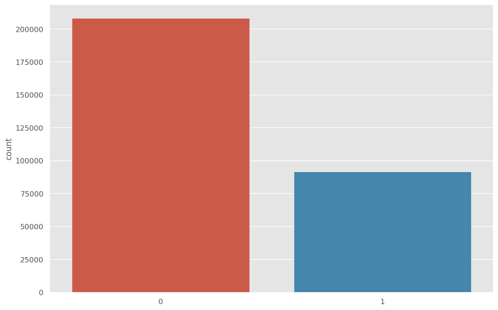

```python
sns.countplot(ytrain)
```

# Useful Codes

```python
def show_method_attributes(obj, ncols=7,start=None, inside=None):
    """ Show all the attributes of a given method.
    Example:
    ========
    show_method_attributes(list)
     """

    print(f'Object Type: {type(obj)}\n')
    lst = [elem for elem in dir(obj) if elem[0]!='_' ]
    lst = [elem for elem in lst
           if elem not in 'os np pd sys time psycopg2'.split() ]

    if isinstance(start,str):
        lst = [elem for elem in lst if elem.startswith(start)]

    if isinstance(start,tuple) or isinstance(start,list):
        lst = [elem for elem in lst for start_elem in start
               if elem.startswith(start_elem)]

    if isinstance(inside,str):
        lst = [elem for elem in lst if inside in elem]

    if isinstance(inside,tuple) or isinstance(inside,list):
        lst = [elem for elem in lst for inside_elem in inside
               if inside_elem in elem]

    return pd.DataFrame(np.array_split(lst,ncols)).T.fillna('')
```

```python
from sklearn.model_selection import train_test_split
from sklearn.linear_model import LogisticRegression
from sklearn.metrics import accuracy_score

def logistic(X,y):
    Xtrain,Xtest,ytrain,ytest=train_test_split(X,y,random_state=SEED,test_size=0.2)
    lr=LogisticRegression(solver='lbfgs',n_jobs=-1)
    lr.fit(Xtrain,ytrain)
    ypreds=lr.predict(Xtest)
    acc = accuracy_score(ytest,ypreds)
    return acc
```

```python
df_results = pd.DataFrame({'Encoding': [],
                           'Wall_Time(s)': [],
                           'num_cols': [],
                           'Accuracy':[]}
                          )
df_results
```

|  | Encoding | Wall_Time(s) | num_cols | Accuracy |
| --- | --- | --- | --- | --- |

# Method 1: Label Encoding

```python
def label_encoder_pandas(df_train, df_test, cols_encode=None, target=None):
    """Label Encoding using pandas

    Inputs: pandas dataframes
    Ouputs: pandas dataframes

    """
    from pandas.api.types import is_string_dtype, is_numeric_dtype


    df_train_new = df_train.drop(target, axis=1).copy()
    df_test_new = df_test.drop(target, axis=1).copy()

    for n,c in df_train_new.items():
        if is_string_dtype(c) or n in cols_encode : df_train_new[n] = c.astype('category').cat.as_ordered()

    if df_test_new is not None:
        for n,c in df_test_new.items():
            if (n in df_train_new.columns) and (df_train_new[n].dtype.name=='category'):
                df_test_new[n] = pd.Categorical(c, categories=df_train_new[n].cat.categories, ordered=True)

    cols = list(df_train_new.columns[df_train_new.dtypes == 'category'])
    for c in cols:
        df_train_new[c] = df_train_new[c].astype('category').cat.codes
        if df_test_new is not None: df_test_new[c] = df_test_new[c].astype('category').cat.codes

    return df_train_new, df_test_new


def label_encoder_no_missing(df_train, df_test, cols_encode, target=None):
    """ Label encoding using scikit-learn

    Inputs: pandas dataframe
    Outputs: pandas dataframe

    This method fails if we encounter new lables in test data.

    """
    from sklearn.preprocessing import LabelEncoder

    df_train_new = df_train.copy()
    df_test_new  = df_test.copy()

    le = LabelEncoder()

    for c in  cols_encode:
        # fit on train and use on test
        le.fit(df_train_new[c])

        # transform
        df_train_new[c] = le.transform(df_train_new[c])
        df_test_new[c]  = le.transform(df_test_new[c])


    return df_train_new, df_test_new


# Label encoder using pandas
from collections import defaultdict
from sklearn.base import BaseEstimator,TransformerMixin
from pandas.api.types import CategoricalDtype

class PandasLabelEncoder(BaseEstimator,TransformerMixin):
    def __init__(self):
        self.label_dict = defaultdict(list)

    def fit(self, X):
        X = X.astype('category')
        cols = X.columns
        values = list(map(lambda col: X[col].cat.categories, cols))
        self.label_dict = dict(zip(cols,values))
        return self

    def transform(self,X):
        # check missing columns
        missing_col=set(X.columns)-set(self.label_dict.keys())
        if missing_col:
            raise ValueError('The column named {} is not in the label dictionary.\
                              Check your fitting data.'.format(missing_col))
        return X.apply(lambda x: x.astype('category').cat.set_categories(
                        self.label_dict[x.name]).cat.codes).astype('category')

    def inverse_transform(self,X):
        return X.apply(lambda x: pd.Categorical.from_codes(codes=x.values,
                                    categories=self.label_dict[x.name]))
```

```python
start = time.time()

enc = PandasLabelEncoder()
enc.fit(df_Xtrain)

df_Xtr = enc.transform(df_Xtrain)


# model
ncols = df_Xtr.shape[1]
acc = logistic(df_Xtr,ytrain)
walltime = round(time.time() - start, 0)

row = ['Label Encoding', walltime , ncols, acc]
df_results.loc[len(df_results)] = row

df_results = df_results.drop_duplicates(subset=['Encoding'])
df_results = df_results.sort_values('Accuracy',ascending=False)
df_results
```

|  | Encoding | Wall_Time(s) | num_cols | Accuracy |
| --- | --- | --- | --- | --- |
| 0 | Label Encoding | 10.0 | 23.0 | 0.696167 |

```python
# df_Xtx = enc.transform(df_test) # this gives -1 for missing values
```

```python
start = time.time()

from sklearn.preprocessing import LabelEncoder


df_Xtr = pd.DataFrame()
le = LabelEncoder()
for c in  df_Xtrain.columns:
    if(df_Xtrain[c].dtype=='object'):
        df_Xtr[c]=le.fit_transform(df_Xtrain[c])
    else:
        df_Xtr[c]=df_Xtrain[c]

# model
ncols = df_Xtr.shape[1]
acc = logistic(df_Xtr,ytrain)
walltime = round(time.time() - start, 0)

row = ['Label Encoding', walltime , ncols, acc]
df_results.loc[len(df_results)] = row

df_results = df_results.drop_duplicates(subset=['Encoding'])
df_results = df_results.sort_values('Accuracy',ascending=False)
df_results
```

|  | Encoding | Wall_Time(s) | num_cols | Accuracy |
| --- | --- | --- | --- | --- |
| 0 | Label Encoding | 10.0 | 23.0 | 0.696167 |

# Method 2 : One Hot Encoding

- Pandas `get_dummies` gives dataframe which uses large memory
- `pd.get_dummies(df_Xtrain, columns=cols_encode, drop_first=True, sparse=True).sparse.to_coo().tocsr()`
- Scikit-learns `OneHotEncoder` uses sparse matrix and takes low memory.

```python
def one_hot_encoder(df_train, df_test, cols_encode, target=None):
    """ one hot encoding
    Inputs : pandas dataframe
    Outputs: OHE gives sparse array

    """
    from sklearn.preprocessing import OneHotEncoder

    ohe_enc = OneHotEncoder(handle_unknown='ignore')
    ohe_enc.fit(df_train[cols_encode])
    train_ohe = ohe_enc.transform(df_train[cols_encode])
    test_ohe = ohe_enc.transform(df_test[cols_encode])
    return train_ohe, test_ohe
```

```python
start = time.time()

# encoding
Xtr,Xtx = one_hot_encoder(df_train,df_test,cols_encode)

# modelling
ncols = Xtr.shape[1]
acc = logistic(Xtr,ytr)
walltime = round(time.time() - start, 0)

row = ['One Hot Encoding', walltime , ncols, acc]
df_results.loc[len(df_results)] = row

df_results = df_results.drop_duplicates(subset=['Encoding'])
df_results = df_results.sort_values('Accuracy',ascending=False)
df_results
```

|  | Encoding | Wall_Time(s) | num_cols | Accuracy |
| --- | --- | --- | --- | --- |
| 1 | One Hot Encoding | 10.0 | 16461.0 | 0.760317 |
| 0 | Label Encoding | 10.0 | 23.0 | 0.696167 |

```python
start = time.time()

from sklearn.preprocessing import OneHotEncoder

# encoding
enc = OneHotEncoder()
Xtr = enc.fit_transform(df_Xtrain)

# modelling
ncols = Xtr.shape[1]
acc = logistic(Xtr,ytr)
walltime = round(time.time() - start, 0)

row = ['One Hot Encoding', walltime , ncols, acc]
df_results.loc[len(df_results)] = row

df_results = df_results.drop_duplicates(subset=['Encoding'])
df_results = df_results.sort_values('Accuracy',ascending=False)
df_results
```

|  | Encoding | Wall_Time(s) | num_cols | Accuracy |
| --- | --- | --- | --- | --- |
| 1 | One Hot Encoding | 10.0 | 16461.0 | 0.760317 |
| 0 | Label Encoding | 10.0 | 23.0 | 0.696167 |

# Method 3 : Feature Hashing

- Feature hashing creates a sparse matrix but with a much lower dimensions.

```python
def hash_encoder_pandas_slow(df_train, df_test, cols_encode, target=None, n_features=10):
    """Feature Hasher Encoder
    n_features=1048576 # default value

    """
    from sklearn.feature_extraction import FeatureHasher


    df_train_hash = df_train.copy().reset_index(drop=True)
    df_test_hash  = df_test.copy().reset_index(drop=True)

    df_train_hash[cols_encode] = df_train_hash[cols_encode].astype(str)
    df_test_hash[cols_encode] = df_test_hash[cols_encode].astype(str)

    hasher = FeatureHasher(n_features=n_features, input_type="string")

    for c in cols_encode:
        hasher.fit(df_train_hash[c])

        columns = [c + f'_{i}' for i in range(n_features)]
        df_tmp_tr = pd.DataFrame(hasher.transform(df_train_hash[c]).toarray(),columns=columns)
        df_tmp_tx = pd.DataFrame(hasher.transform(df_test_hash[c]).toarray(), columns=columns)

        df_train_hash = df_train_hash.drop(c,axis=1).join(df_tmp_tr)
        df_test_hash  = df_test_hash.drop(c,axis=1).join(df_tmp_tx)

    return df_train_hash, df_test_hash
```

```python
def hash_encoder(df_train, df_test, cols_encode, target=None, n_features=10):
    """Feature Hasher Encoder
    n_features=1048576 # default value

    """
    from sklearn.feature_extraction import FeatureHasher


    Xtr_hash     = df_train[cols_encode].astype(str).to_numpy()
    Xtr_no_hash  = df_train[[c for c in df_train.columns if c not in cols_encode]].to_numpy()

    Xtx_hash     = df_test[cols_encode].astype(str).to_numpy()
    Xtx_no_hash  = df_test[[c for c in df_test.columns if c not in cols_encode]].to_numpy()

    hasher = FeatureHasher(n_features=n_features, input_type="string")
    hasher.fit(Xtr_hash)

    Xtr_hash = hasher.transform(Xtr_hash).toarray()
    Xtx_hash = hasher.transform(Xtx_hash).toarray()

    train_hash = np.c_[Xtr_no_hash, Xtr_hash]
    test_hash  = np.c_[Xtx_no_hash, Xtx_hash]

    return train_hash, test_hash
```

```python
df_Xtr, df_Xtx = hash_encoder_pandas_slow(df_Xtrain, df_Xtest, ['bin_1','nom_1'],n_features=10)

df_Xtr.head(1).values
```

```
array([[0, 0, 'T', 'Y', 'Green', 'Snake', 'Finland', 'Bassoon',
        '50f116bcf', '3ac1b8814', '68f6ad3e9', 'c389000ab', '2f4cb3d51',
        2, 'Grandmaster', 'Cold', 'h', 'D', 'kr', 2, 2, 0.0, 0.0, 0.0,
        0.0, 0.0, 0.0, 0.0, 0.0, 0.0, -1.0, 1.0, -2.0, 0.0, 0.0, -1.0,
        1.0, 0.0, 0.0, 0.0, 1.0]], dtype=object)
```

```python
Xtr, Xtx = hash_encoder(df_Xtrain, df_Xtest, ['bin_1','nom_1'],n_features=10)

Xtr[0]
```

```
array([0, 0, 'T', 'Y', 'Green', 'Snake', 'Finland', 'Bassoon',
       '50f116bcf', '3ac1b8814', '68f6ad3e9', 'c389000ab', '2f4cb3d51', 2,
       'Grandmaster', 'Cold', 'h', 'D', 'kr', 2, 2, 0.0, 0.0, 0.0, 0.0,
       0.0, 1.0, 0.0, 0.0, 0.0, -1.0], dtype=object)
```

```python
start = time.time()

# encoding
cols_encode = df_Xtrain.columns

n_features = 1000 # sesson crashes in gcolab if n_features > 1000
Xtr, Xtx = hash_encoder(df_Xtrain, df_Xtest, cols_encode,n_features=n_features)

# modelling
ncols = Xtr.shape[1]
acc = logistic(Xtr,ytr)
walltime = round(time.time() - start, 0)

row = [f'Feature Hasher function {n_features}', walltime , ncols, acc]
df_results.loc[len(df_results)] = row

df_results = df_results.drop_duplicates(subset=['Encoding'])
df_results = df_results.sort_values('Accuracy',ascending=False)
df_results
```

|  | Encoding | Wall_Time(s) | num_cols | Accuracy |
| --- | --- | --- | --- | --- |
| 1 | One Hot Encoding | 10.0 | 16461.0 | 0.760317 |
| 2 | Feature Hasher function 1000 | 162.0 | 1000.0 | 0.735717 |
| 0 | Label Encoding | 10.0 | 23.0 | 0.696167 |

```python
start = time.time()

# encoding
from sklearn.feature_extraction import FeatureHasher

df_Xtr = df_Xtrain.astype('str').copy()

n_features = 1048576 # default 1048576
hasher = FeatureHasher(input_type='string')

Xtr = hasher.fit_transform(df_Xtr.to_numpy())

# model
ncols = Xtr.shape[1]
acc = logistic(Xtr,ytr)
walltime = round(time.time() - start, 0)

row = ['Feature Hasher default', walltime , ncols, acc]
df_results.loc[len(df_results)] = row

df_results = df_results.drop_duplicates(subset=['Encoding'])
df_results = df_results.sort_values('Accuracy',ascending=False)
df_results
```

|  | Encoding | Wall_Time(s) | num_cols | Accuracy |
| --- | --- | --- | --- | --- |
| 1 | One Hot Encoding | 10.0 | 16461.0 | 0.760317 |
| 3 | Feature Hasher default | 30.0 | 1048576.0 | 0.753600 |
| 2 | Feature Hasher function 1000 | 162.0 | 1000.0 | 0.735717 |
| 0 | Label Encoding | 10.0 | 23.0 | 0.696167 |

```python
start = time.time()

# encoding
from sklearn.feature_extraction import FeatureHasher

df_Xtr = df_Xtrain.astype('str').copy()

n_features = 1048576 # default 1048576
hasher = FeatureHasher(input_type='string',n_features=100)

Xtr = hasher.fit_transform(df_Xtr.to_numpy())

# model
ncols = Xtr.shape[1]
acc = logistic(Xtr,ytr)
walltime = round(time.time() - start, 0)

row = ['Feature Hasher 100', walltime , ncols, acc]
df_results.loc[len(df_results)] = row

df_results = df_results.drop_duplicates(subset=['Encoding'])
df_results = df_results.sort_values('Accuracy',ascending=False)
df_results
```

|  | Encoding | Wall_Time(s) | num_cols | Accuracy |
| --- | --- | --- | --- | --- |
| 1 | One Hot Encoding | 10.0 | 16461.0 | 0.760317 |
| 3 | Feature Hasher default | 30.0 | 1048576.0 | 0.753600 |
| 2 | Feature Hasher function 1000 | 162.0 | 1000.0 | 0.735717 |
| 4 | Feature Hasher 100 | 8.0 | 100.0 | 0.707100 |
| 0 | Label Encoding | 10.0 | 23.0 | 0.696167 |

# Method 4 :Encoding categories with dataset statistics

- Replace category names by value counts and add noise

```python
start = time.time()

# encoding
df_Xtr = df_Xtrain.copy()
for c in df_Xtr.columns:
    if(df_Xtr[c].dtype=='object'):
        df_Xtr[c]= df_Xtr[c].astype('category')
        counts = df_Xtr[c].value_counts()
        counts = counts.sort_index()
        counts = counts.fillna(0)
        counts += np.random.rand(len(counts))/1000
        df_Xtr[c].cat.categories = counts

# model
ncols = df_Xtr.shape[1]
acc = logistic(df_Xtr,ytr)
walltime = round(time.time() - start, 0)

row = ['Value counts + Random Noise', walltime , ncols, acc]
df_results.loc[len(df_results)] = row

df_results = df_results.drop_duplicates(subset=['Encoding'])
df_results = df_results.sort_values('Accuracy',ascending=False)
df_results
```

|  | Encoding | Wall_Time(s) | num_cols | Accuracy |
| --- | --- | --- | --- | --- |
| 1 | One Hot Encoding | 10.0 | 16461.0 | 0.760317 |
| 3 | Feature Hasher default | 30.0 | 1048576.0 | 0.753600 |
| 2 | Feature Hasher function 1000 | 162.0 | 1000.0 | 0.735717 |
| 4 | Feature Hasher 100 | 8.0 | 100.0 | 0.707100 |
| 0 | Label Encoding | 10.0 | 23.0 | 0.696167 |
| 5 | Value counts + Random Noise | 11.0 | 23.0 | 0.695650 |

# Method 5: Encoding Cyclic Features

```python
start = time.time()

# encoding
df_Xtr = df_Xtrain.copy()

# cyclic encoding
cols_cyclic =['day','month']

for col in cols_cyclic:
    df_Xtr[col+'_sin'] = np.sin((2*np.pi* df_Xtr[col])/max(df_Xtr[col]))
    df_Xtr[col+'_cos'] = np.cos((2*np.pi*df_Xtr[col])/max(df_Xtr[col]))
    df_Xtr.drop(col,axis=1,inplace=True)

# use ohe after cyclic encoding
ohe = OneHotEncoder()
Xtr = ohe.fit_transform(df_Xtr)

# model
ncols = Xtr.shape[1]
acc = logistic(Xtr,ytr)
walltime = round(time.time() - start, 0)

row = ['Cyclic + OHE', walltime , ncols, acc]
df_results.loc[len(df_results)] = row

df_results = df_results.drop_duplicates(subset=['Encoding'])
df_results = df_results.sort_values('Accuracy',ascending=False)
df_results
```

|  | Encoding | Wall_Time(s) | num_cols | Accuracy |
| --- | --- | --- | --- | --- |
| 6 | Cyclic + OHE | 10.0 | 16478.0 | 0.760783 |
| 1 | One Hot Encoding | 10.0 | 16461.0 | 0.760317 |
| 3 | Feature Hasher default | 30.0 | 1048576.0 | 0.753600 |
| 2 | Feature Hasher function 1000 | 162.0 | 1000.0 | 0.735717 |
| 4 | Feature Hasher 100 | 8.0 | 100.0 | 0.707100 |
| 0 | Label Encoding | 10.0 | 23.0 | 0.696167 |
| 5 | Value counts + Random Noise | 11.0 | 23.0 | 0.695650 |

```python
# encoding
df_Xtr = df_Xtrain.copy()

# cyclic encoding
cols_cyclic = ['day','month']

for col in cols_cyclic:
    df_Xtr[col+'_sin'] = np.sin((2*np.pi* df_Xtr[col])/max(df_Xtr[col]))
    df_Xtr[col+'_cos'] = np.cos((2*np.pi*df_Xtr[col])/max(df_Xtr[col]))
    df_Xtr.drop(col,axis=1,inplace=True)


df_Xtr.head(2)
```

|  | bin_0 | bin_1 | bin_2 | bin_3 | bin_4 | nom_0 | nom_1 | nom_2 | nom_3 | nom_4 | nom_5 | nom_6 | nom_7 | nom_8 | nom_9 | ord_0 | ord_1 | ord_2 | ord_3 | ord_4 | ord_5 | day_sin | day_cos | month_sin | month_cos |
| --- | --- | --- | --- | --- | --- | --- | --- | --- | --- | --- | --- | --- | --- | --- | --- | --- | --- | --- | --- | --- | --- | --- | --- | --- | --- |
| 0 | 0 | 0 | 0 | T | Y | Green | Triangle | Snake | Finland | Bassoon | 50f116bcf | 3ac1b8814 | 68f6ad3e9 | c389000ab | 2f4cb3d51 | 2 | Grandmaster | Cold | h | D | kr | 9.749279e-01 | -0.222521 | 0.866025 | 0.5 |
| 1 | 0 | 1 | 0 | T | Y | Green | Trapezoid | Hamster | Russia | Piano | b3b4d25d0 | fbcb50fc1 | 3b6dd5612 | 4cd920251 | f83c56c21 | 1 | Grandmaster | Hot | a | A | bF | -2.449294e-16 | 1.000000 | -0.866025 | -0.5 |

# Method 6: Target Encoding

```python
df_train.head(2)
```

|  | bin_0 | bin_1 | bin_2 | bin_3 | bin_4 | nom_0 | nom_1 | nom_2 | nom_3 | nom_4 | nom_5 | nom_6 | nom_7 | nom_8 | nom_9 | ord_0 | ord_1 | ord_2 | ord_3 | ord_4 | ord_5 | day | month | target |
| --- | --- | --- | --- | --- | --- | --- | --- | --- | --- | --- | --- | --- | --- | --- | --- | --- | --- | --- | --- | --- | --- | --- | --- | --- |
| 0 | 0 | 0 | 0 | T | Y | Green | Triangle | Snake | Finland | Bassoon | 50f116bcf | 3ac1b8814 | 68f6ad3e9 | c389000ab | 2f4cb3d51 | 2 | Grandmaster | Cold | h | D | kr | 2 | 2 | 0 |
| 1 | 0 | 1 | 0 | T | Y | Green | Trapezoid | Hamster | Russia | Piano | b3b4d25d0 | fbcb50fc1 | 3b6dd5612 | 4cd920251 | f83c56c21 | 1 | Grandmaster | Hot | a | A | bF | 7 | 8 | 0 |

```python
df_train.select_dtypes('object').columns
```

```
Index(['bin_3', 'bin_4', 'nom_0', 'nom_1', 'nom_2', 'nom_3', 'nom_4', 'nom_5',
       'nom_6', 'nom_7', 'nom_8', 'nom_9', 'ord_1', 'ord_2', 'ord_3', 'ord_4',
       'ord_5'],
      dtype='object')
```

```python
start = time.time()

# encoding

df_tr = df_train.copy()

df_tr['day']   = df_tr['day'].astype('object')
df_tr['month'] = df_tr['month'].astype('object')

for col in df_tr.columns:
    if (df_tr[col].dtype=='object'):
        ser_col_target_mean = df_tr.groupby(col)['target'].mean()
        df_tr[col] = df_tr[col].map(ser_col_target_mean)

# modelling
df_Xtr = df_tr.drop('target',axis=1)
ncols = df_Xtr.shape[1]
acc = logistic(df_Xtr,ytr)
walltime = round(time.time() - start, 0)

row = ['Target Encoding', walltime , ncols, acc]
df_results.loc[len(df_results)] = row

df_results = df_results.drop_duplicates(subset=['Encoding'])
df_results = df_results.sort_values('Accuracy',ascending=False)
df_results
```

|  | Encoding | Wall_Time(s) | num_cols | Accuracy |
| --- | --- | --- | --- | --- |
| 7 | Target Encoding | 10.0 | 23.0 | 0.784817 |
| 6 | Cyclic + OHE | 10.0 | 16478.0 | 0.760783 |
| 1 | One Hot Encoding | 10.0 | 16461.0 | 0.760317 |
| 3 | Feature Hasher default | 30.0 | 1048576.0 | 0.753600 |
| 2 | Feature Hasher function 1000 | 162.0 | 1000.0 | 0.735717 |
| 4 | Feature Hasher 100 | 8.0 | 100.0 | 0.707100 |
| 0 | Label Encoding | 10.0 | 23.0 | 0.696167 |
| 5 | Value counts + Random Noise | 11.0 | 23.0 | 0.695650 |

# Method 7: KFold target encoding

```python
def kfold_target_encoder(df_train, df_test, cols_encode, target,
                         folds=5,random_state=SEED):
    """Target encoding using mean regularized kfold.
    """

    from sklearn.model_selection import KFold

    df_train_new = df_train.copy()
    df_test_new = df_test.copy()

    kf = KFold(n_splits=folds, random_state=SEED,shuffle=False)

    for col in cols_encode:
        train_mean = df_train_new[target].mean()
        for train_index, test_index in kf.split(df_train):
            mean_target = df_train_new.iloc[train_index].groupby(col)[target].mean()
            df_train_new.loc[test_index, col + "_mean_enc"] = \
                df_train_new.loc[test_index, col].map(mean_target)

        # fill nans for train
        df_train_new[col + "_mean_enc"].fillna(train_mean, inplace=True)

        # encoding for test using train
        map_col_mean = df_train_new.groupby(col)[target].mean()
        df_test_new[col + "_mean_enc"] = df_test_new[col].map(map_col_mean)
        df_test_new[col + "_mean_enc"].fillna(train_mean, inplace=True)

    # filter only mean enc cols
    df_train_new = df_train_new.filter(like="mean_enc", axis=1)
    df_test_new  = df_test_new.filter(like="mean_enc", axis=1)
    return df_train_new, df_test_new
```

```python
df_train.columns
```

```
Index(['bin_0', 'bin_1', 'bin_2', 'bin_3', 'bin_4', 'nom_0', 'nom_1', 'nom_2',
       'nom_3', 'nom_4', 'nom_5', 'nom_6', 'nom_7', 'nom_8', 'nom_9', 'ord_0',
       'ord_1', 'ord_2', 'ord_3', 'ord_4', 'ord_5', 'day', 'month', 'target'],
      dtype='object')
```

```python
start = time.time()

# encoding

df_tr = df_train.copy()
df_tx = df_test.copy()

df_tr['day']   = df_tr['day'].astype('object')
df_tr['month'] = df_tr['month'].astype('object')

df_tx['day']   = df_tx['day'].astype('object')
df_tx['month'] = df_tx['month'].astype('object')

cols_encode = df_train.columns.drop(['target'])
target = 'target'

df_Xtr, df_Xtx = kfold_target_encoder(df_tr, df_tx, cols_encode, target)

# modelling
ncols = df_Xtr.shape[1]
acc = logistic(df_Xtr,ytr)
walltime = round(time.time() - start, 0)

row = ['KFold Target Encoding', walltime , ncols, acc]
df_results.loc[len(df_results)] = row

df_results = df_results.drop_duplicates(subset=['Encoding'])
df_results = df_results.sort_values('Accuracy',ascending=False)
df_results
```

|  | Encoding | Wall_Time(s) | num_cols | Accuracy |
| --- | --- | --- | --- | --- |
| 7 | Target Encoding | 10.0 | 23.0 | 0.784817 |
| 8 | KFold Target Encoding | 22.0 | 23.0 | 0.761950 |
| 6 | Cyclic + OHE | 10.0 | 16478.0 | 0.760783 |
| 1 | One Hot Encoding | 10.0 | 16461.0 | 0.760317 |
| 3 | Feature Hasher default | 30.0 | 1048576.0 | 0.753600 |
| 2 | Feature Hasher function 1000 | 162.0 | 1000.0 | 0.735717 |
| 4 | Feature Hasher 100 | 8.0 | 100.0 | 0.707100 |
| 0 | Label Encoding | 10.0 | 23.0 | 0.696167 |
| 5 | Value counts + Random Noise | 11.0 | 23.0 | 0.695650 |

# Method 8: Thermometer encoding

```python
from sklearn.base import BaseEstimator, TransformerMixin


class ThermometerEncoder(BaseEstimator, TransformerMixin):
    """Thermometer encoding for numerical categorical features.

    Thermometer encoding is also called Unary coding and is an entropy encoding.


    Example:
    df_thermo = pd.DataFrame({'A': [1,2,3], 'B': ['one','two','three'],
                          'C': [10,20,30]})

    enc = ThermometerEncoder(['A'])
    out = enc.fit_transform(df_thermo)

    This gives:
    1 ==> 000
    2 ==> 110
    3 ==> 211

    For column C ==> C_10 to C_29, it gives 20 columns.


    Thermometer encoding with length 8
    -----------------------------------
    x = [2, 3, 4, 1, 0, 8]
    length = 8
    out = (np.arange(length) < np.array(x).reshape(-1, 1)).astype(int)

    References:
    1. https://www.wikiwand.com/en/Unary_coding
    2. https://stackoverflow.com/questions/49080613/numpy-thermometer-encoding
    3. https://www.kaggle.com/pavelvpster/cat-in-dat-ohe-vs-thermometer-logit
    4. https://github.com/kmedian/thermoencoder (python module, only works
       with numeric value like this class, but it has inverse transform)
    5. https://github.com/adwardlee/thermometer-encoding (for keras)

    """

    def __init__(self, cols=None, drop_invariant=True):
        self.cols = cols
        self.drop_invariant = drop_invariant

    def get_params(self, deep=True):
        return {'cols': self.cols, 'drop_invariant': self.drop_invariant}

    def set_params(self, **parameters):
        for parameter, value in parameters.items():
            setattr(self, parameter, value)
        return self

    def fit(self, X, y=None):
        self.bars = {}
        for c in self.cols:
            k = np.arange(X[c].max() + 1)
            self.bars[c] = (k[:-1] < k.reshape(-1, 1)).astype(int)
        return self

    def transform(self, X, y=None):
        out = pd.DataFrame(index=X.index)
        for c in self.cols:
            out = out.join(self.transform_one(X, c))

        if self.drop_invariant:
            columns_to_drop = []
            for c in out.columns:
                if len(out[c].unique()) == 1:
                    columns_to_drop.append(c)
            out = out.drop(columns_to_drop, axis=1)

        return out

    def transform_one(self, X, c):
        bars = self.bars[c]
        out = pd.DataFrame(index=X.index, data=bars[X[c]])
        out.columns = [c + '_' + str(k) for k in range(bars.shape[1])]
        return out
```

```python
df_thermo = pd.DataFrame({'A': [1,2,3], 'B': ['one','two','three'],
                          'C': [10,20,30]})
df_thermo
```

|  | A | B | C |
| --- | --- | --- | --- |
| 0 | 1 | one | 10 |
| 1 | 2 | two | 20 |
| 2 | 3 | three | 30 |

```python
ThermometerEncoder(['A']).fit_transform(df_thermo)
"""
1 ==> 000
2 ==> 110
3 ==> 211

"""
```

|  | A_1 | A_2 |
| --- | --- | --- |
| 0 | 0 | 0 |
| 1 | 1 | 0 |
| 2 | 1 | 1 |

```python
enc = ThermometerEncoder(['C'])

tmp = enc.fit_transform(df_thermo)
print(tmp.shape)
tmp
```

```
(3, 20)
```

|  | C_10 | C_11 | C_12 | C_13 | C_14 | C_15 | C_16 | C_17 | C_18 | C_19 | C_20 | C_21 | C_22 | C_23 | C_24 | C_25 | C_26 | C_27 | C_28 | C_29 |
| --- | --- | --- | --- | --- | --- | --- | --- | --- | --- | --- | --- | --- | --- | --- | --- | --- | --- | --- | --- | --- |
| 0 | 0 | 0 | 0 | 0 | 0 | 0 | 0 | 0 | 0 | 0 | 0 | 0 | 0 | 0 | 0 | 0 | 0 | 0 | 0 | 0 |
| 1 | 1 | 1 | 1 | 1 | 1 | 1 | 1 | 1 | 1 | 1 | 0 | 0 | 0 | 0 | 0 | 0 | 0 | 0 | 0 | 0 |
| 2 | 1 | 1 | 1 | 1 | 1 | 1 | 1 | 1 | 1 | 1 | 1 | 1 | 1 | 1 | 1 | 1 | 1 | 1 | 1 | 1 |

```python
df_Xtrain.select_dtypes('number').head()
```

|  | bin_0 | bin_1 | bin_2 | ord_0 | day | month |
| --- | --- | --- | --- | --- | --- | --- |
| 0 | 0 | 0 | 0 | 2 | 2 | 2 |
| 1 | 0 | 1 | 0 | 1 | 7 | 8 |
| 2 | 0 | 0 | 0 | 1 | 7 | 2 |
| 3 | 0 | 1 | 0 | 1 | 2 | 1 |
| 4 | 0 | 0 | 0 | 1 | 7 | 8 |

```python
df_Xtrain['ord_0'].unique()
```

```
array([2, 1, 3])
```

```python
# %%time

# # pandas get dummies is extremely slow, use scikit-learn
# df_Xdummies = pd.get_dummies(df_Xtrain, columns=cols_ohe, drop_first=True)
# print(df_Xdummies.shape)
# df_Xdummies.head(2)

# # Wall time: 2min 2s
```

```python
# %%time

# from sklearn.preprocessing import OneHotEncoder

# enc = OneHotEncoder()

# Xtr_sparse = enc.fit_transform(df_Xtrain.to_numpy())

# # Wall time: 1.87 s
```

```python
start = time.time()

# encoding
import scipy
from sklearn.preprocessing import OneHotEncoder

# one hot encoder
enc = OneHotEncoder()
Xtr_sparse = enc.fit_transform(df_Xtrain.to_numpy())

# thermomter encoding for categorical features with numeric values
cols_thermo = ['ord_0','day','month']
thermo = ThermometerEncoder(cols_thermo)
thermo.fit(df_Xtrain)
df_Xthermo = thermo.transform(df_Xtrain)

X_thermo_sparse = scipy.sparse.csr_matrix(df_Xthermo.to_numpy())
Xtr_sparse_all  = scipy.sparse.hstack([Xtr_sparse, X_thermo_sparse])

# modelling
ncols = Xtr_sparse_all.shape[1]
acc = logistic(Xtr_sparse_all,ytr)
walltime = round(time.time() - start, 0)

row = ['Thermometer + OHE', walltime , ncols, acc]
df_results.loc[len(df_results)] = row

df_results = df_results.drop_duplicates(subset=['Encoding'])
df_results = df_results.sort_values('Accuracy',ascending=False)
df_results
```

|  | Encoding | Wall_Time(s) | num_cols | Accuracy |
| --- | --- | --- | --- | --- |
| 7 | Target Encoding | 10.0 | 23.0 | 0.784817 |
| 8 | KFold Target Encoding | 22.0 | 23.0 | 0.761950 |
| 6 | Cyclic + OHE | 10.0 | 16478.0 | 0.760783 |
| 9 | Thermometer + OHE | 11.0 | 16480.0 | 0.760700 |
| 1 | One Hot Encoding | 10.0 | 16461.0 | 0.760317 |
| 3 | Feature Hasher default | 30.0 | 1048576.0 | 0.753600 |
| 2 | Feature Hasher function 1000 | 162.0 | 1000.0 | 0.735717 |
| 4 | Feature Hasher 100 | 8.0 | 100.0 | 0.707100 |
| 0 | Label Encoding | 10.0 | 23.0 | 0.696167 |
| 5 | Value counts + Random Noise | 11.0 | 23.0 | 0.695650 |

[output not shown]